# USP654 Lab 3: Multiple Regression

Liming Wang

10/09/2017

## Descriptive statistics among multiple variables

### Correlation Matrix

With base R function `cor`:

```r
#install.packages("tidyverse")
library(tidyverse)

mtcars %>% cor
```

```
##             mpg        cyl       disp         hp        drat         wt        qsec         vs          am       gear        carb
## mpg   1.0000000 -0.8521620 -0.8475514 -0.7761684  0.68117191 -0.8676594  0.41868403  0.6640389  0.59983243  0.4802848 -0.55092507
## cyl  -0.8521620  1.0000000  0.9020329  0.8324475 -0.69993811  0.7824958 -0.59124207 -0.8108118 -0.52260705 -0.4926866  0.52698829
## disp -0.8475514  0.9020329  1.0000000  0.7909486 -0.71021393  0.8879799 -0.43369788 -0.7104159 -0.59122704 -0.5555692  0.39497686
## hp   -0.7761684  0.8324475  0.7909486  1.0000000 -0.44875912  0.6587479 -0.70822339 -0.7230967 -0.24320426 -0.1257043  0.74981247
## drat  0.6811719 -0.6999381 -0.7102139 -0.4487591  1.00000000 -0.7124406  0.09120476  0.4402785  0.71271113  0.6996101 -0.09078980
## wt   -0.8676594  0.7824958  0.8879799  0.6587479 -0.71244065  1.0000000 -0.17471588 -0.5549157 -0.69249526 -0.5832870  0.42760594
## qsec  0.4186840 -0.5912421 -0.4336979 -0.7082234  0.09120476 -0.1747159  1.00000000  0.7445354 -0.22986086 -0.2126822 -0.65624923
## vs    0.6640389 -0.8108118 -0.7104159 -0.7230967  0.44027846 -0.5549157  0.74453544  1.0000000  0.16834512  0.2060233 -0.56960714
## am    0.5998324 -0.5226070 -0.5912270 -0.2432043  0.71271113 -0.6924953 -0.22986086  0.1683451  1.00000000  0.7940588  0.05753435
## gear  0.4802848 -0.4926866 -0.5555692 -0.1257043  0.69961013 -0.5832870 -0.21268223  0.2060233  0.79405876  1.0000000  0.27407284
## carb -0.5509251  0.5269883  0.3949769  0.7498125 -0.09078980  0.4276059 -0.65624923 -0.5696071  0.05753435  0.2740728  1.00000000
```

For fancier outputs, install the `corrr` package:

```r
install.packages("corrr")
library(corrr)
```

Half correlation matrix:

```r
mtcars %>%
  correlate() %>%
  shave() %>%
  fashion()
```

```
##    rowname  mpg  cyl disp   hp drat   wt qsec   vs   am gear carb
## 1      mpg
## 2      cyl -.85
## 3     disp -.85  .90
## 4       hp -.78  .83  .79
## 5     drat  .68 -.70 -.71 -.45
## 6       wt -.87  .78  .89  .66 -.71
## 7     qsec  .42 -.59 -.43 -.71  .09 -.17
## 8       vs  .66 -.81 -.71 -.72  .44 -.55  .74
## 9       am  .60 -.52 -.59 -.24  .71 -.69 -.23  .17
## 10    gear  .48 -.49 -.56 -.13  .70 -.58 -.21  .21  .79
## 11    carb -.55  .53  .39  .75 -.09  .43 -.66 -.57  .06  .27
```

Visulize correlation matrix:

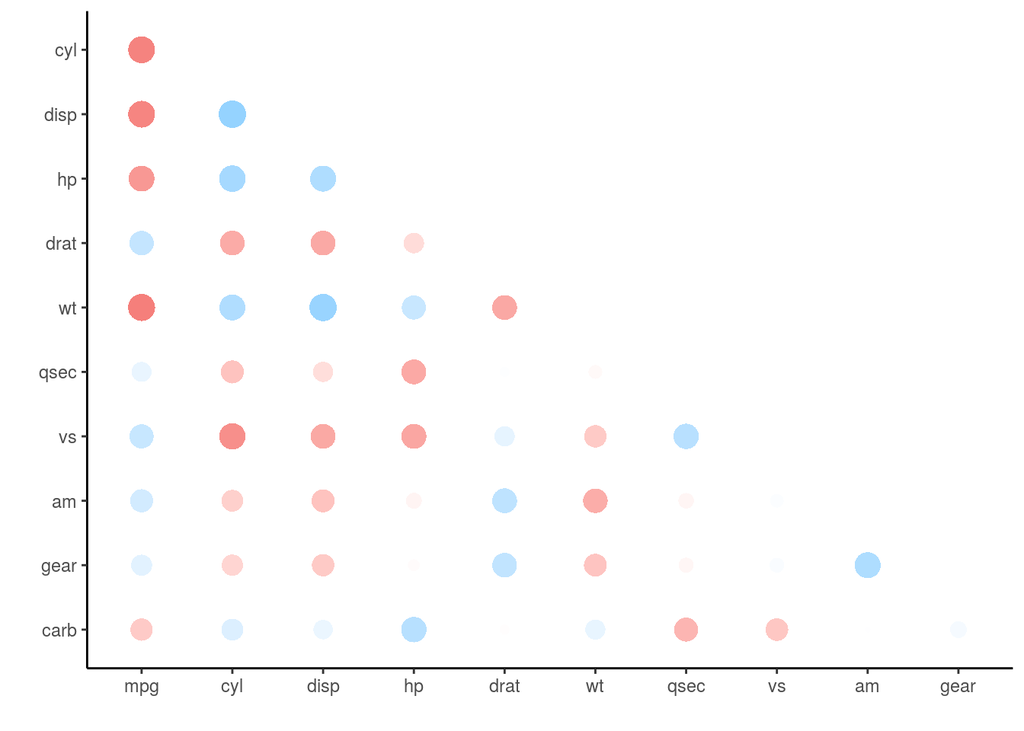

```r
mtcars %>%
  correlate() %>%
  shave() %>%
  rplot()
```

### Scatterplot Matrix

(Looking at the first 6 variables, as the figure becomes illegible when all variables are shown).

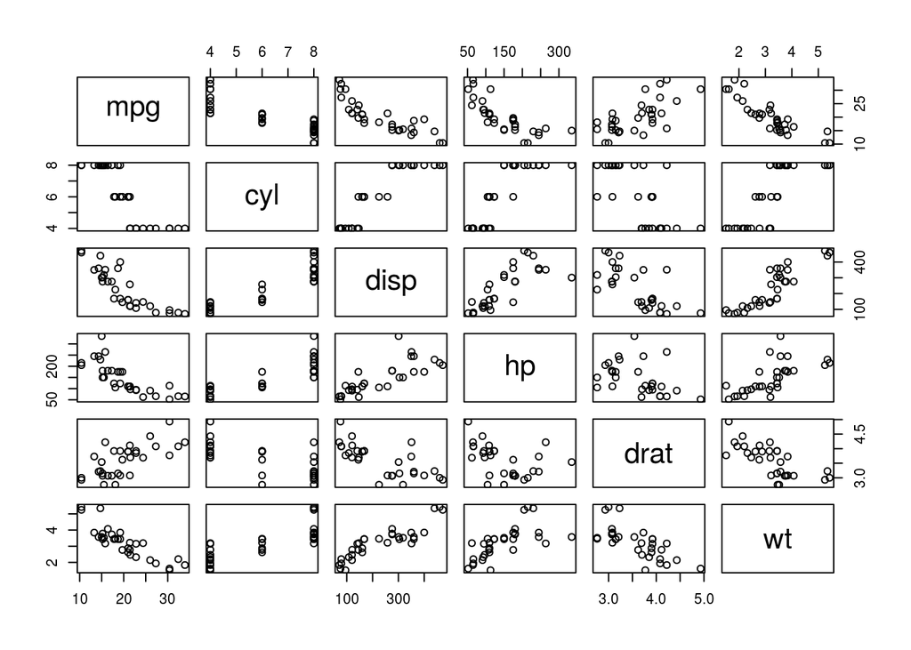

```r
mtcars[1:6] %>%
  plot
```

Better looking version with `GGally` package

```r
install.packages("GGally")
```

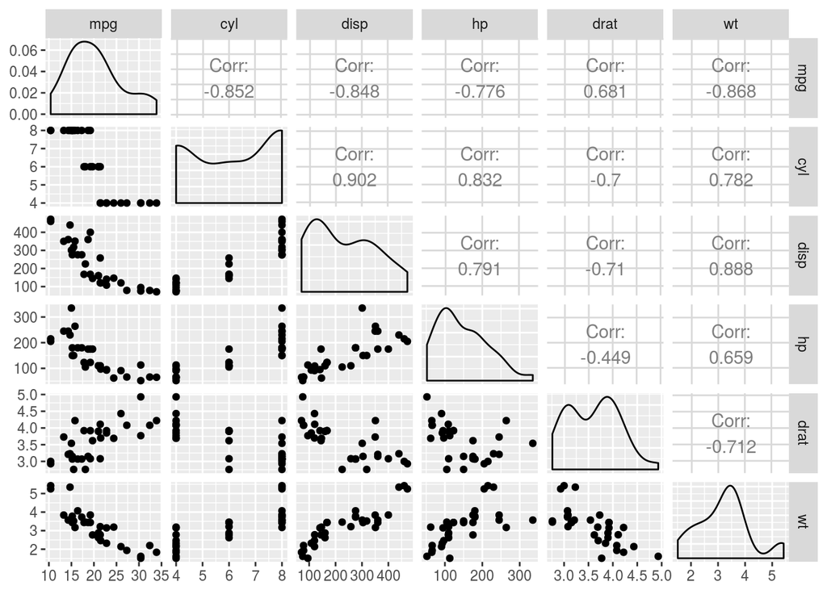

```r
library(GGally)
ggpairs(data=mtcars[1:6])
```

## Multiple Regression

In R, run multiple regressions with `lm` (short for **l**inear **m**odel):

```r
lm(mpg ~ wt + cyl, data=mtcars)
```

```
##
## Call:
## lm(formula = mpg ~ wt + cyl, data = mtcars)
##
## Coefficients:
## (Intercept)           wt          cyl
##      39.686       -3.191       -1.508
```

## More detailed regression results

1. Pass the results from `lm()` to `summary()` for more detailed information:

```r
lm(mpg ~ wt + cyl, data=mtcars) %>%
  summary()
```

```
##
## Call:
## lm(formula = mpg ~ wt + cyl, data = mtcars)
##
## Residuals:
##     Min      1Q  Median      3Q     Max
## -4.2893 -1.5512 -0.4684  1.5743  6.1004
##
## Coefficients:
##             Estimate Std. Error t value Pr(>|t|)
## (Intercept)  39.6863     1.7150  23.141  < 2e-16 ***
## wt           -3.1910     0.7569  -4.216 0.000222 ***
## cyl          -1.5078     0.4147  -3.636 0.001064 **
## ---
## Signif. codes:  0 '***' 0.001 '**' 0.01 '*' 0.05 '.' 0.1 ' ' 1
##
## Residual standard error: 2.568 on 29 degrees of freedom
## Multiple R-squared:  0.8302, Adjusted R-squared:  0.8185
## F-statistic: 70.91 on 2 and 29 DF,  p-value: 6.809e-12
```

For better formatting of the results (pretty print), we can use the `texreg` package:

```r
## Install and load texreg package
install.packages("texreg")
library(texreg)

# Pretty print regression results on screen
lm(mpg ~ wt + cyl, data=mtcars) %>%
  screenreg()
```

```
##
## ======================
##              Model 1
## ----------------------
## (Intercept)  39.69 ***
##              (1.71)
## wt           -3.19 ***
##              (0.76)
## cyl          -1.51 **
##              (0.41)
## ----------------------
## R^2           0.83
## Adj. R^2      0.82
## Num. obs.    32
## RMSE          2.57
## ======================
## *** p < 0.001, ** p < 0.01, * p < 0.05
```

```r
# Save regression results to a html file
lm(mpg ~ wt + cyl, data=mtcars) %>%
  htmlreg(file="output/lm_mpg-wt+cyl.html")
```

2. Confidence interval of coefficients

```r
lm(mpg ~ wt + cyl, data=mtcars) %>%
  confint()
```

```
##                 2.5 %     97.5 %
## (Intercept) 36.178725 43.1937976
## wt          -4.739020 -1.6429245
## cyl         -2.355928 -0.6596622
```

## Visualize regression results

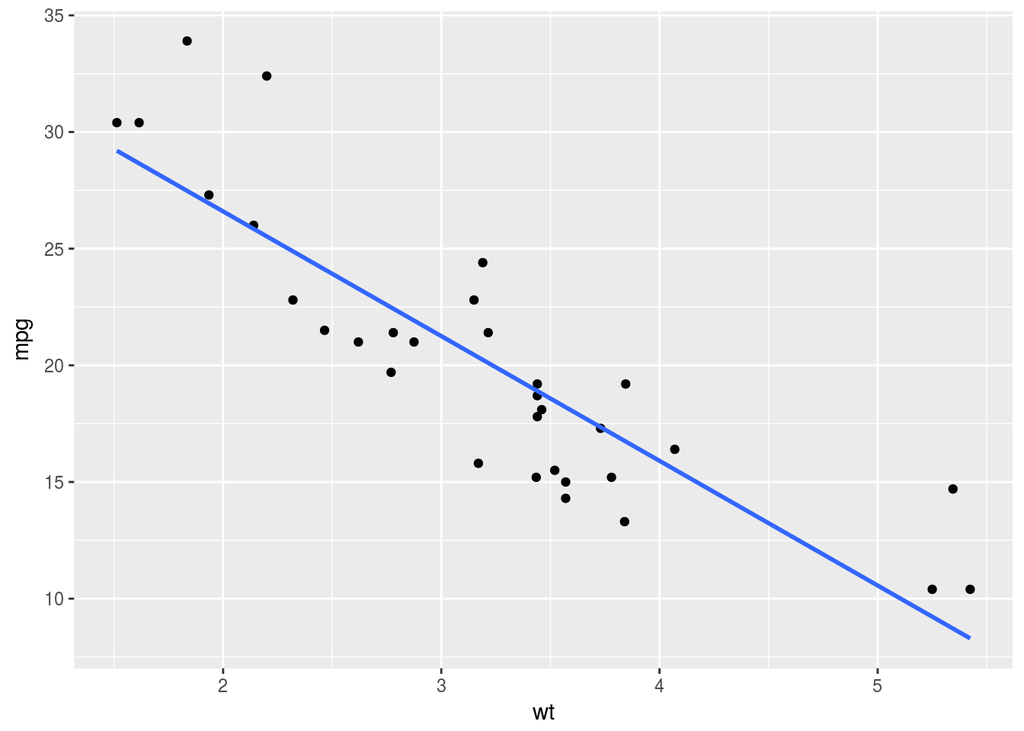

```r
ggplot(mtcars, aes(x=wt, y=mpg)) + geom_point() + geom_smooth(method = "lm", se = FALSE)
```

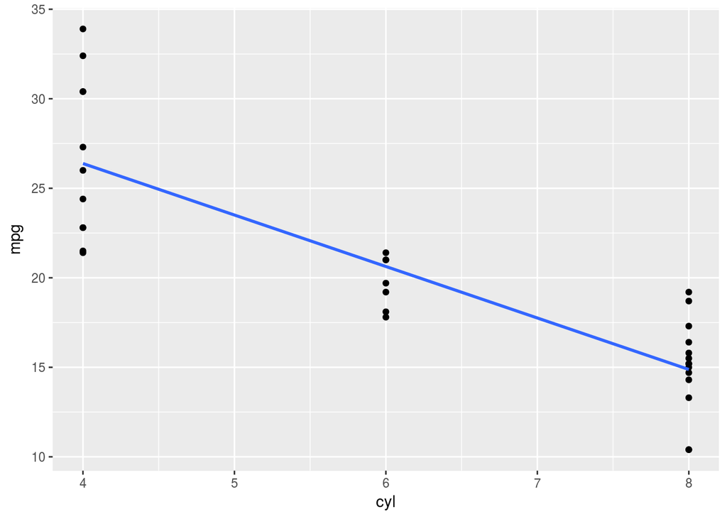

```r
ggplot(mtcars, aes(x=cyl, y=mpg)) + geom_point() + geom_smooth(method = "lm", se = FALSE)
```

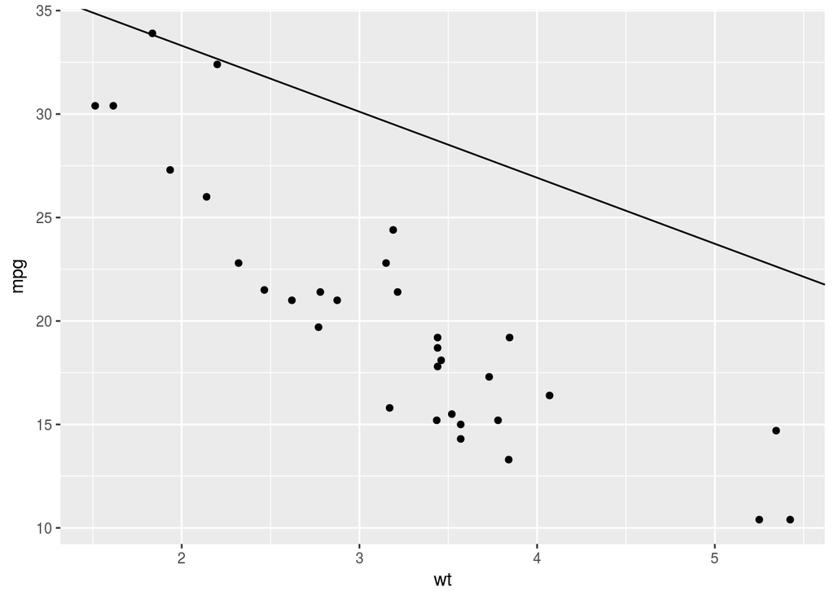

```r
betas <- lm(mpg ~ wt + cyl, data=mtcars) %>% summary() %>% coef()
ggplot(mtcars, aes(x=wt, y=mpg)) + geom_point() +
  geom_abline(aes(slope=betas["wt", "Estimate"], intercept=betas["(Intercept)", "Estimate"]))
```

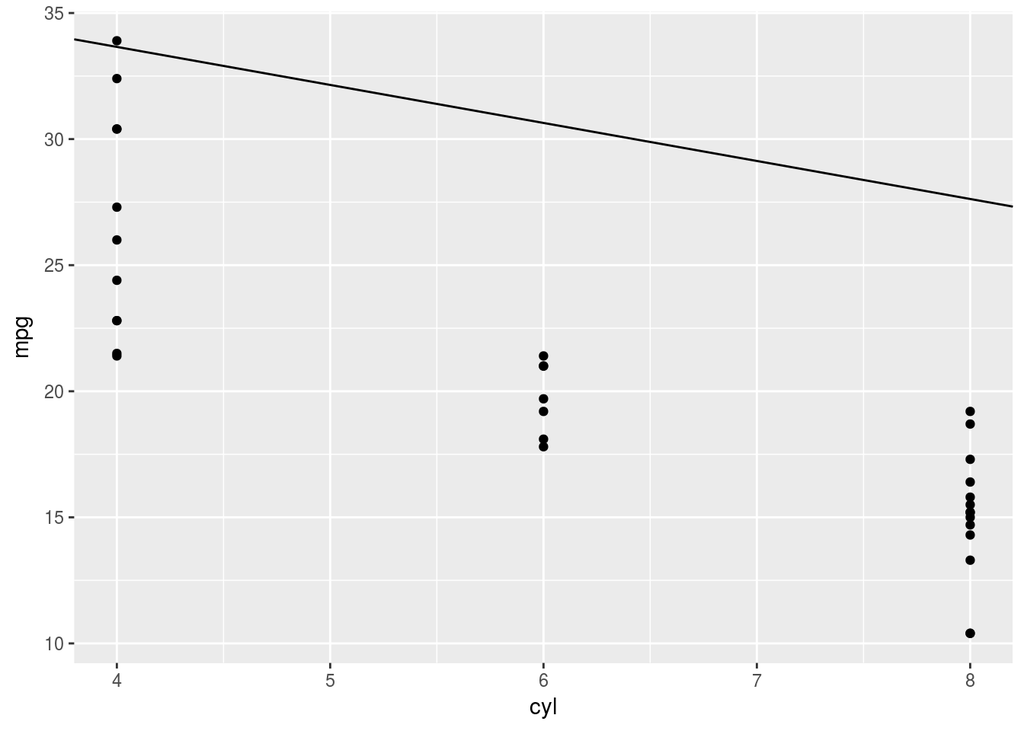

```r
ggplot(mtcars, aes(x=cyl, y=mpg)) + geom_point() +
  geom_abline(aes(slope=betas["cyl", "Estimate"], intercept=betas["(Intercept)", "Estimate"]))
```

## Hypothesis testing of nested models

```r
## Install and load ggfortify package

lm_mpg_wt <- lm(mpg ~ wt, data=mtcars)
lm_mpg_wt.cyl <- lm(mpg ~ wt + cyl, data=mtcars)

anova(lm_mpg_wt, lm_mpg_wt.cyl)
```

```
## Analysis of Variance Table
##
## Model 1: mpg ~ wt
## Model 2: mpg ~ wt + cyl
##   Res.Df    RSS Df Sum of Sq     F   Pr(>F)
## 1     30 278.32
## 2     29 191.17  1     87.15 13.22 0.001064 **
## ---
## Signif. codes:  0 '***' 0.001 '**' 0.01 '*' 0.05 '.' 0.1 ' ' 1
```

## Tasks

1. Create a new RStudio project and create directory structure following the recommendation in [Project Management With RStudio](http://swcarpentry.github.io/r-novice-gapminder/02-project-intro/);
2. Select a dataset from the [Tools and Datasets] section of the course website or use your own dataset, save the dataset in the data folder of your project;
3. Famarlize yourself with your dataset with the data document;
4. Create a script that imports your dataset into R and explores it with descriptive statistics and/or visulization;
5. Choose a dependent variable and a couple of independent variables and run regression models;
6. Create regression plots (scatter plot superimposed with a regression line) & diagnostic plots.

## Resources

- [Introduction to R on Data Camp](https://campus.datacamp.com/courses/free-introduction-to-r/chapter-1-intro-to-basics-1?ex=1): A self-instruction course covering R basics.
- [R coding basics on Software Carpentry](http://swcarpentry.github.io/r-novice-gapminder/), hands-on tutorial on R basics, lesson 4-11.